# Ford GoBike System Data Exploration

## by Jonathan Abuh

## Investigation Overview

In this analysis, I would like to figure that when and where are most trips taken, and what kind of characteristics are in these locations and time periods. The characteristics include rider's attributes (sex, age, and user_type) and duration of trips.

## Dataset Overview

This dataset includes 15340 trips with 24 features such as duration, user type, and weekday. There are start and end stations. I observed that majority of trips took place at the same stations, so I subset the dataset by choosing top 5 trips start stations with the most trips. Thus, the following analysis is performed by this subsetted dataset.

# Univariate Visualization

What I set to achieve in this exploration is to find out factors that makes a rider spend long time on bike trips?

#### Q: Is the data of duration normally distributed ?

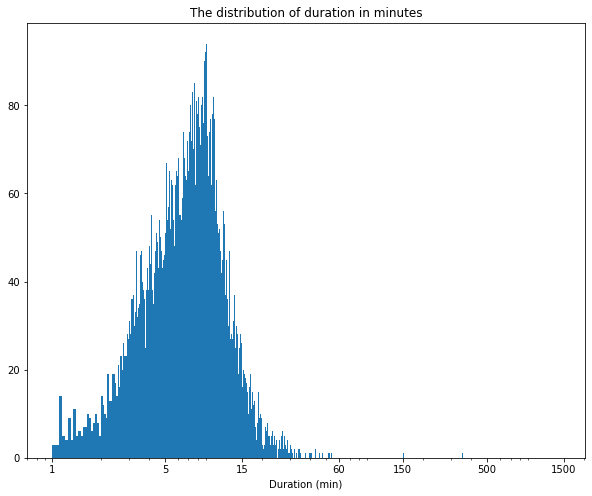

**The top 5 stations with the most trips**

#### Q: What are the top 5 stations with most trips?

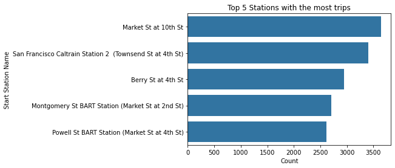

##### From the plot above, it is evident that the Market St at 10th St is the station with the most trips and Powell St BART Station (Market St at 4th St) is the least among the top 5 stations.

### The time with most trips

There are more bike trips in the morining than in the afternoon and night time. The bike rides in the afternoon is more than that of the night time. Factors that could possibly contribute to the reduced bike rides can be poor visibility and personal safety.

There are more trips on weekdays than on weekends. This is probably because riders commute to their places of work on weekdays using these go bikes.

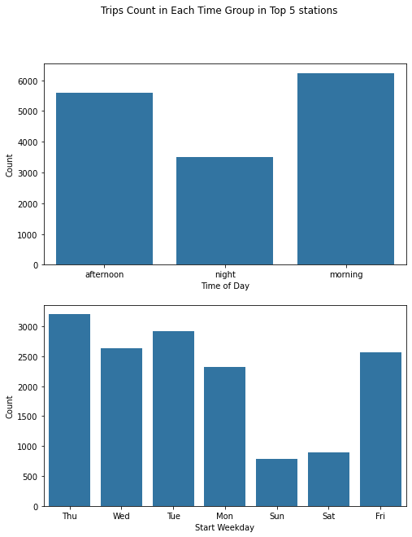

## Bivariate Visualization

We will investigate the relationships between various pairs of variables, in this section, to try and answer the below question.

#### Q: What is the distribution of Top 5 Stations by Times (time of the day and weekday)?

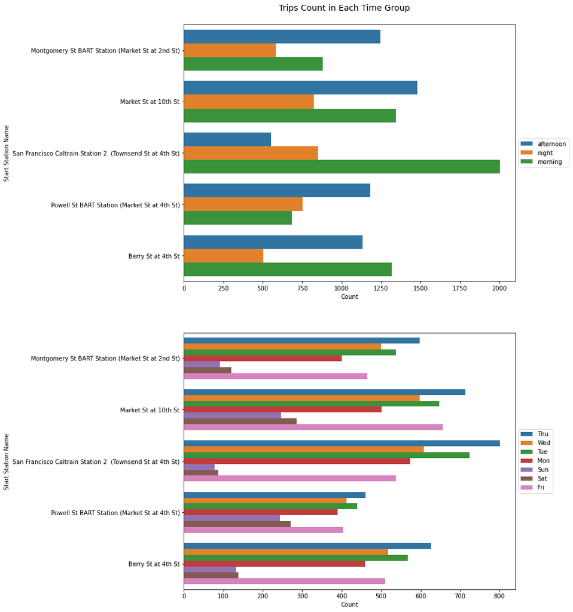

#### Q: What is the distribution for the top 5 stations by users' attributes (user_type, member's gender)?

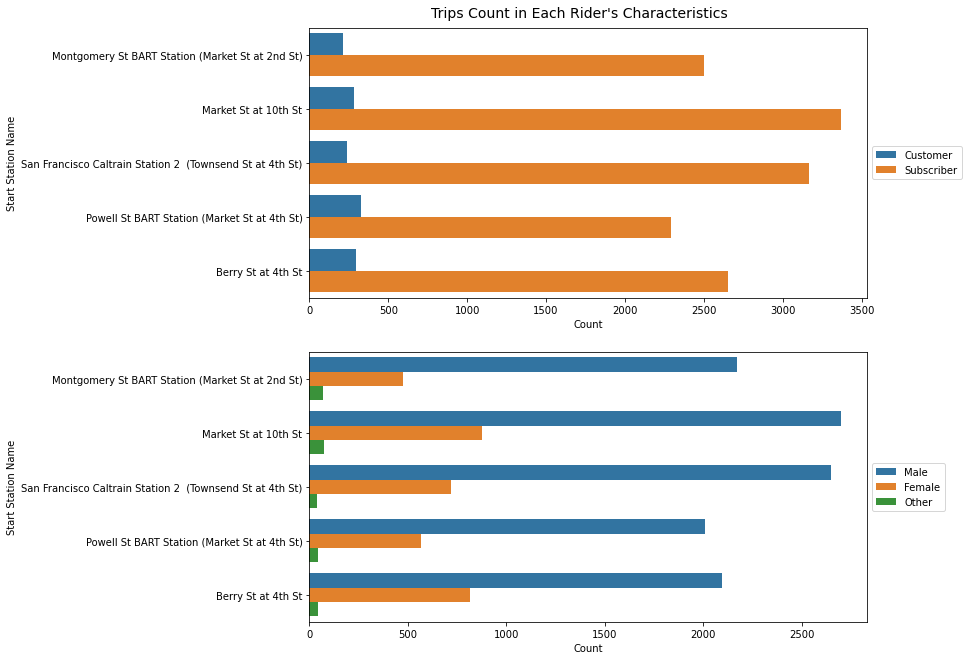

From the chart above, the following were observed:

It is obvious that subscribers are more than the regular customers. Also, Market St at 10th St and San Francisco Caltrain Station 2 (Townsend St at 4th St) are the stations with the most trips count.

The chart reveals that the males has the highest trips count as compared to the females.

#### Q: What is the distribution to show the the top 5 stations by age and trips duration?

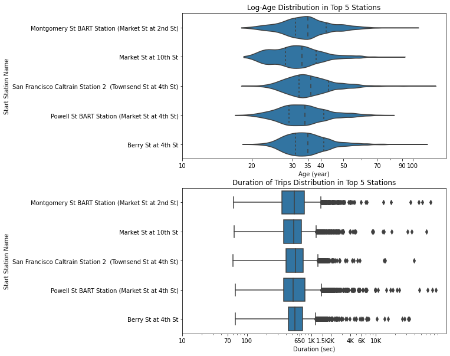

I discovered that Market St at 10 St has the lowest median and San Francisco Caltrain Station 2 (Towsend St at 4th St) has the highest median. Most of median age population (between 30 to 40) is consistent in each station.

For the duration of trips in the top 5 stations, Powell St BART Station (Market St at 4th St) has the lowest median.

## Multivariate Visualization

### The top 5 stations with the most trips by weekdays in each user type

Subscribers make less trips during the weekend and more trips during weekdays.

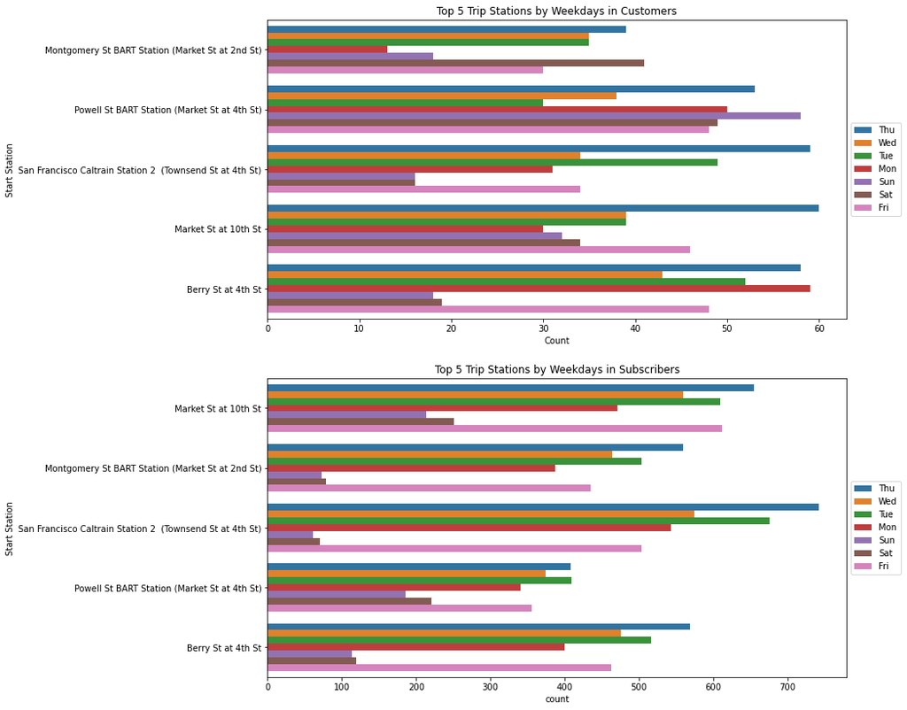